# Homework2

Zach Schroeder

5/6/2021

Background For this homework, we will use a dataset on adolescent alcohol use collected by Curran et al., which includes three waves of data on 82 adolescents. Below is some additional information about the data.

Waves of data were collected annually, beginning at age 14 alcuse is the outcome, ranging from 0 (“not at all”) to 7 (“every day”). A square root transformation has been applied. coa is a dummy variabe indicating whether or not the participant was the child of and alcoholic. peer is measure of alcohol use among the participant’s peer group. Similar to the outcome, a square root transformation has been applied.

1: Data Read in the data and conduct any data prep work needed. Specifically, we will be fitting a number of different growth models in this homework, so you’ll need to think about how you’re going to code time.

```r
data <- read_csv(here::here("data", "alcohol-adolescents(hw2).csv"))
data$coa <- data$coa
data$male <- factor(data$male)
data$wave <- data$age - 14
data$peer <- round(data$peer, 0)
```

*I have created a “wave” variable that begins at 0, thus allowing for meaningful interpretation of the intercept in subsequent models.*

2: Initial fits Fit a model with random intercepts and parallel slopes. Compare the fit of this model to a one with random intercepts and random slopes. Describe which model you believe fits the data better, and provide evidence to justify this conclusion.

```r
rips <- lmer(alcuse ~ wave + (1|id),data)
rirs <- lmer(alcuse ~ wave + (wave|id), data)
performance::compare_performance(rips, rirs,
                    metrics = c("AIC", "BIC"),
                    rank = TRUE) %>%
  as_tibble()
```

```
## # A tibble: 2 x 5
##   Name  Model     AIC   BIC Performance_Score
##   <chr> <chr>   <dbl> <dbl>             <dbl>
## 1 rips  lmerMod  662.  676.               0.5
## 2 rirs  lmerMod  655.  676.               0.5
```

*Comparing fits using the AIC and BIC suggests that the Random Slopes model has better fit, however, it is only slightly better on the AIC metric, the BIC metric does not show an improvement. This suggests that we are approaching overfitting and need to proceed with caution. As such, my preference is for the parallel slopes model as it is simpler and fits the data comparably well.*

3: Alternative residual VCOV Use Generalized Least Squares (gls) to re-estimate the model with (a) autoregressive, (b) heterogeneous autoregressive, and (c) Toeplitz structures. Compare the composite residuals from these models with the composite residual from the random slopes model fit in Question 2.

```r
#RANDOM SLOPES MODEL COMPOSITE RESIDUAL
rirs_rvcv <- sundry::pull_residual_vcov(rirs)
rirs_rvcv[1:3, 1:3]
```

```
## 3 x 3 sparse Matrix of class "dgCMatrix"
##           1         2         3
## 1 0.9728275 0.5641682 0.4928011
## 2 0.5641682 0.9852448 0.7317369
## 3 0.4928011 0.7317369 1.3079650
```

```r
#AUTOREGRESSIVE MODEL
ar <- gls(alcuse ~ wave,
          data = data,
          correlation = corAR1(form = ~ 1|id))

#Extracting composite residuals
cm_ar <- corMatrix(ar$modelStruct$corStruct)
cr_ar <- cm_ar[[1]]
ar_rvcv <- cr_ar * sigma(ar)^2

# HETEROGENOUS AUTOREGRESSIVE MODEL
har <- gls(
  alcuse ~ wave,
  data = data,
  correlation = corAR1(form = ~ 1|id),
  weights = varIdent(form = ~1|wave)
)

#Extract composite residuals
cm_har <- corMatrix(har$modelStruct$corStruct)[[1]]
var_struct <- har$modelStruct$varStruct
vars <- coef(var_struct, unconstrained = FALSE, allCoef = TRUE)
vars <- matrix(vars, ncol = 1)
har_rvcv <- cm_har * sigma(har)^2 *
  (vars %*% t(vars))

#TOEPLITZ MODEL
toep <- gls(alcuse ~ wave,
            data = data,
            correlation = corARMA(form = ~ 1|id, p = 2))
cr_toep <- corMatrix(toep$modelStruct$corStruct)[[1]]
toep_rvcv <- cr_toep * sigma(toep)^2
```

Composite residuals:

```r
rirs_rvcv[1:3, 1:3]
```

```
## 3 x 3 sparse Matrix of class "dgCMatrix"
##           1         2         3
## 1 0.9728275 0.5641682 0.4928011
## 2 0.5641682 0.9852448 0.7317369
## 3 0.4928011 0.7317369 1.3079650
```

```r
ar_rvcv[1:3, 1:3]
```

```
##           [,1]      [,2]      [,3]
## [1,] 1.0876493 0.6729905 0.4164175
## [2,] 0.6729905 1.0876493 0.6729905
## [3,] 0.4164175 0.6729905 1.0876493
```

```r
har_rvcv[1:3, 1:3]
```

```
##           [,1]      [,2]      [,3]
## [1,] 0.8713981 0.6093846 0.4146972
## [2,] 0.6093846 1.0954631 0.7454823
## [3,] 0.4146972 0.7454823 1.3040920
```

```r
toep_rvcv[1:3, 1:3]
```

```
##           [,1]      [,2]      [,3]
## [1,] 1.0877040 0.6731349 0.4378666
## [2,] 0.6731349 1.0877040 0.6731349
## [3,] 0.4378666 0.6731349 1.0877040
```

*Structurally, in this model, the AR and Toepliz models have similar structures to their composite residuals - they have banded residuals that decay as they go outward. The random slopes and HAR models have similar residuals structures, with parallel bands the in the other direction and more variability in the residuals than the AR or the Toepliz models*

4: Comparing models Compare the fit of all models. Which model does the evidence suggest provides the best fit to the data?

```r
performance::compare_performance(ar, har, toep, rips, rirs,
                    metrics = c("AIC", "BIC"),
                    rank = TRUE) %>%
  as_tibble()
```

```
## # A tibble: 5 x 5
##   Name  Model     AIC   BIC Performance_Score
##   <chr> <chr>   <dbl> <dbl>             <dbl>
## 1 ar    gls      652.  666.           0.985
## 2 har   gls      652.  673.           0.668
## 3 toep  gls      654.  672.           0.622
## 4 rirs  lmerMod  655.  676.           0.337
## 5 rips  lmerMod  662.  676.           0.00677
```

5: Adding predictors Include coa and peer as predictors in the model. Evaluate whether adolescents alcohol use trajectories (slopes) depend on these variables. You can extend your {lme4} model or your gls() model, regardless of your conclusions from above. Provide a brief summary of your findings (you do not have to interpret the entire model, just whether or not the trajectories depend on coa and/or peer).

```r
ripsc <- lmer(alcuse ~ wave + coa + (coa|id),data)
ripsp <- lmer(alcuse ~ wave + peer + (peer|id),data)
ripspp <- lmer(alcuse ~ wave + coa + peer + (wave|id),data)
ripspc <- lmer(alcuse ~ wave + coa + peer + (peer|id) + (coa|id),data)
```

```
## boundary (singular) fit: see ?isSingular
```

```r
performance::compare_performance(rips, ripsc, ripsp, ripspc,
                    metrics = c("AIC", "BIC"),
                    rank = TRUE) %>%
  as_tibble()
```

```
## # A tibble: 4 x 5
##   Name   Model     AIC   BIC Performance_Score
##   <chr>  <chr>   <dbl> <dbl>             <dbl>
## 1 ripsp  lmerMod  645.  670.             0.990
## 2 ripspc lmerMod  645.  683.             0.5
## 3 ripsc  lmerMod  655.  679.             0.360
## 4 rips   lmerMod  662.  676.             0.262
```

```r
coef <- broom.mixed::tidy(
  ripsp,
  effects = "ran_pars",
  conf.int = TRUE,
  conf.method = "boot"
)
```

```
## Computing bootstrap confidence intervals ...
```

```
##
## 183 message(s): boundary (singular) fit: see ?isSingular
## 33 warning(s): Model failed to converge with max|grad| = 0.00208658 (tol = 0.002, component 1) (and others)
```

6: Plots Produce the following plot. Don’t worry about differences in the theming. Just get the basics structure. Note, I’m using the model that I felt displayed the best fit to the data to make my predictions.

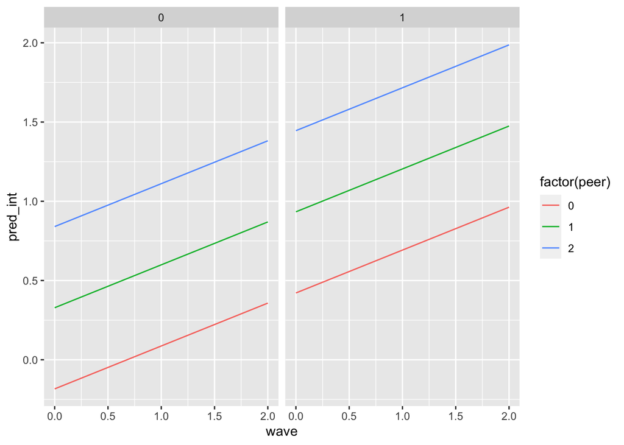

```r
pred_frame <- expand.grid(
  peer = 0:2,
  coa = 0:1,
  wave = 0:2,
  id = -999
)

pred_frame <- pred_frame %>%
  mutate(pred = predict(ripspp,
                        pred_frame,
                        allow.new.levels = TRUE))

pred_frame <- pred_frame %>%
  mutate(pred_int = predict(ripspp,
                            newdata = pred_frame,
                            allow.new.levels = TRUE))
pred_frame %>%
  drop_na() %>%
  ggplot(aes(wave, pred_int)) +
  geom_line(aes(color = factor(peer))) +
  facet_wrap(~coa)
```